# Item Drift Between Semesters - Fall 2025 vs. Spring 2026

Author

RW

# Packages

```r
library(tidyverse)
library(lme4)
library(easystats)
source("R/item-analysis.R")
library(emmeans)
```

# Data

Both semesters are built from the raw instructor files so they get the same cleaning.

```r
exams <- c("exam_01", "exam_02", "exam_03")

long <- c("fall", "spring") |>
  set_names() |>
  map(\(term) exams |> map(\(e) read_exam(e, term = term)) |> list_rbind()) |>
  list_rbind(names_to = "semester")
```

## Bad items

Flagged within each semester, then dropped from both so the comparison uses the same items.

```r
bad_items <- long |>
  split(~semester) |>
  map(flag_bad_items) |>
  list_rbind(names_to = "semester")

bad_items |> count(semester, exam, name = "n_removed")
```

```
# A tibble: 6 × 3
  semester exam    n_removed
  <chr>    <chr>       <int>
1 fall     exam_01         2
2 fall     exam_02         2
3 fall     exam_03         4
4 spring   exam_01         4
5 spring   exam_02         4
6 spring   exam_03        10
```

```r
clean <- long |>
  anti_join(bad_items, by = c("exam", "question_title")) |>
  filter(
    !(exam == "exam_03" &
      str_detect(question_title, "^For the last four questions"))
  )
```

## Items shared across semesters

Drift can only be measured on items that appear in both semesters.

```r
shared_items <- clean |>
  distinct(semester, exam, question_title) |>
  count(exam, question_title) |>
  filter(n == 2) |>
  select(-n)

clean_shared <- clean |>
  semi_join(shared_items, by = c("exam", "question_title"))

shared_items |> count(exam, name = "n_shared_items")
```

```
# A tibble: 3 × 2
  exam    n_shared_items
  <chr>            <int>
1 exam_01            101
2 exam_02             78
3 exam_03             66
```

# Descriptive Comparison

Difficulty and discrimination are computed within each semester (tiers are formed within exam × semester).

```r
drift_items <- item_summary(clean_shared, by = "semester")$items |>
  select(exam, semester, question_title, difficulty_index, discrimination_index) |>
  pivot_wider(
    names_from = semester,
    values_from = c(difficulty_index, discrimination_index)
  ) |>
  mutate(
    difficulty_diff = difficulty_index_spring - difficulty_index_fall,
    discrimination_diff = discrimination_index_spring - discrimination_index_fall
  )

drift_summary <- drift_items |>
  summarise(
    n_items = n(),
    mean_difficulty_diff = mean(difficulty_diff, na.rm = TRUE),
    sd_difficulty_diff = sd(difficulty_diff, na.rm = TRUE),
    mean_discrimination_diff = mean(discrimination_diff, na.rm = TRUE),
    sd_discrimination_diff = sd(discrimination_diff, na.rm = TRUE),
    .by = exam
  )

drift_summary
```

```
# A tibble: 3 × 6
  exam    n_items mean_difficulty_diff sd_difficulty_diff mean_discrimination_…¹
  <chr>     <int>                <dbl>              <dbl>                  <dbl>
1 exam_01     101               -0.167              0.118                  0.161
2 exam_02      78               -0.135              0.130                  0.163
3 exam_03      66               -0.205              0.166                  0.255
# ℹ abbreviated name: ¹mean_discrimination_diff
# ℹ 1 more variable: sd_discrimination_diff <dbl>
```

## Difficulty

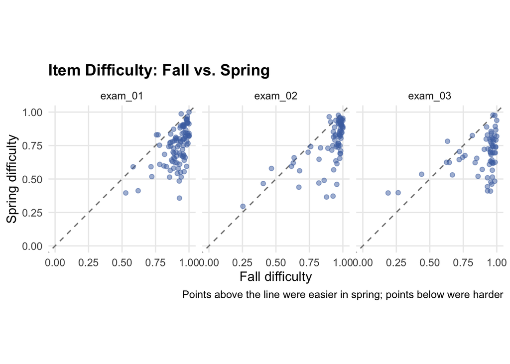

```r
ggplot(drift_items, aes(x = difficulty_index_fall, y = difficulty_index_spring)) +
  geom_abline(linetype = "dashed", color = "grey50") +
  geom_point(alpha = 0.5, color = "#4C72B0") +
  facet_wrap(~exam) +
  coord_equal(xlim = c(0, 1), ylim = c(0, 1)) +
  labs(
    title = "Item Difficulty: Fall vs. Spring",
    caption = "Points above the line were easier in spring; points below were harder",
    x = "Fall difficulty",
    y = "Spring difficulty"
  ) +
  theme_minimal(base_size = 13) +
  theme(plot.title = element_text(face = "bold"), panel.grid.minor = element_blank())
```

## Discrimination

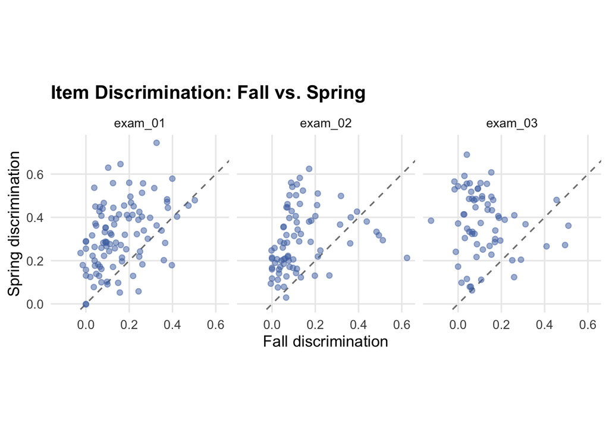

```r
ggplot(drift_items, aes(x = discrimination_index_fall, y = discrimination_index_spring)) +
  geom_abline(linetype = "dashed", color = "grey50") +
  geom_point(alpha = 0.5, color = "#4C72B0") +
  facet_wrap(~exam) +
  coord_equal() +
  labs(
    title = "Item Discrimination: Fall vs. Spring",
    x = "Fall discrimination",
    y = "Spring discrimination"
  ) +
  theme_minimal(base_size = 13) +
  theme(plot.title = element_text(face = "bold"), panel.grid.minor = element_blank())
```

Item discrimination is better in the spring compared to the fall across all three exams, indicated by the majority of points sitting above the line where the spring and fall discrimination are equal.

# Multilevel Model

Same structure as the instructor comparison, with semester in place of instructor for the item-level term. Students are keyed within semester. Instructor stays as a fixed effect because Baber taught only in fall and Wu only in spring; without it, those instructors’ differences would be counted as semester differences.

```r
model_data <- clean_shared |>
  filter(answered) |>
  mutate(
    student = paste(semester, id, sep = "_"),
    item = paste(exam, question_title, sep = " | "),
    across(c(student, item, instructor, exam, semester), as.factor)
  )

model_data <- model_data |>
  mutate(instructor = fct_relevel(instructor, "marshall"))

d0 <- glmer(
  correct ~ exam * semester + instructor + (1 | student) + (1 | item),
  data = model_data,
  family = binomial,
  control = glmerControl(optimizer = "bobyqa")
)

d1 <- update(d0, . ~ . + (1 | item:semester))
```

## Does item difficulty drift between semesters?

The variance is tested at its boundary (zero), so halve the reported p-value.

```r
test_likelihoodratio(d0, d1)
```

```
# Likelihood-Ratio-Test (LRT) for Model Comparison (ML-estimator)

Name |    Model | df | df_diff | Criterion |    Chi2 |      p
-------------------------------------------------------------
d0   | glmerMod | 12 |         |  41111.80 |         |
d1   | glmerMod | 13 |       1 |  40035.30 | 1076.50 | < .001
```

Allowing item difficulty to differ by semester improved fit substantially, $\chi^2(1) = 1076.5, p < .001$. Items shifted between semesters beyond the average exam by semester shift.

```r
model_parameters(d1, effects = "random")
```

```
# Random Effects

Parameter                     | Coefficient | 95% CI
----------------------------------------------------
SD (Intercept: student)       |        0.70 |
SD (Intercept: item:semester) |        0.72 |
SD (Intercept: item)          |        0.86 |
```

```r
icc(d1, by_group = TRUE)
```

```
# ICC by Group

Group         |   ICC
---------------------
student       | 0.097
item:semester | 0.103
item          | 0.147
```

Exam items differed in difficulty by a SD of 0.86 logits. This is the part of item difficulty that holds across both semesters. For a typical Marshall student on a typical Exam 1 item in spring, the odds of a correct answer are 3.97 ($18.06 \times 0.22 = 3.97$; $\ln(3.97) = 1.38$), or a probability of .80. An item 1 SD easier than average has 2.36 times the odds of a correct answer ($\exp(0.86) = 2.36$), or $P = \frac{1}{1 + e^{-(1.38 + 0.86)}} = \frac{1}{1 + 0.106} = .904$ or 90.4%. An item 1 SD harder than average has 0.42 times the odds of a correct answer ($\exp(-0.86) = \frac{1}{e^{0.86}} = \frac{1}{2.36} = 0.42$), or $P = \frac{1}{1 + e^{-(1.38 - 0.86)}} = \frac{1}{1 + 0.595} = .627$ or 62.7%.

Item difficulty shifted within a given semester by a SD of 0.72 logits, beyond that exam’s average fall-to-spring shift. Using the same baseline, an item 1 SD easier in one semester than its overall difficulty would predict has 2.05 times the odds of a correct answer ($\exp(0.72) = 2.05$), or $P = \frac{1}{1 + e^{-(1.38 + 0.72)}} = \frac{1}{1 + 0.122} = .891$ or 89.1%. An item 1 SD harder in one semester has 0.49 times the odds of a correct answer ($\exp(-0.72) = \frac{1}{e^{0.72}} = \frac{1}{2.05} = 0.49$), or $P = \frac{1}{1 + e^{-(1.38 - 0.72)}} = \frac{1}{1 + 0.517} = .659$ or 65.9%.

Students differed in ability by a SD of 0.70 logits. Using the same baseline, a student 1 SD above the mean has 2.01 times the odds of a correct answer ($\exp(0.70) = 2.01$), or $P = \frac{1}{1 + e^{-(1.38 + 0.70)}} = \frac{1}{1 + 0.125} = .889$ or 88.9%. A student 1 SD below the mean has 0.50 times the odds of a correct answer ($\exp(-0.70) = \frac{1}{e^{0.70}} = \frac{1}{2.01} = 0.50$), or $P = \frac{1}{1 + e^{-(1.38 - 0.70)}} = \frac{1}{1 + 0.507} = .664$ or 66.4%.

## Overall semester differences

`semester [spring]` is the shift on Exam 1. The `exam × semester` terms show whether that shift differed on Exams 2 and 3.

```r
model_parameters(d1, effects = "fixed", exponentiate = TRUE)
```

```
# Fixed Effects

Parameter                          | Odds Ratio |   SE |         95% CI
-----------------------------------------------------------------------
(Intercept)                        |      18.06 | 2.61 | [13.60, 23.98]
exam [exam_02]                     |       1.29 | 0.24 | [ 0.90,  1.84]
exam [exam_03]                     |       0.95 | 0.18 | [ 0.65,  1.38]
semester [spring]                  |       0.22 | 0.03 | [ 0.17,  0.29]
instructor [baber]                 |       1.01 | 0.12 | [ 0.81,  1.27]
instructor [okomeng]               |       1.03 | 0.10 | [ 0.85,  1.23]
instructor [wood]                  |       1.12 | 0.11 | [ 0.93,  1.35]
instructor [wu]                    |       0.84 | 0.10 | [ 0.67,  1.05]
exam [exam_02] × semester [spring] |       0.99 | 0.17 | [ 0.70,  1.39]
exam [exam_03] × semester [spring] |       0.71 | 0.13 | [ 0.50,  1.00]

Parameter                          |      z |      p
----------------------------------------------------
(Intercept)                        |  20.02 | < .001
exam [exam_02]                     |   1.39 | 0.165
exam [exam_03]                     |  -0.27 | 0.786
semester [spring]                  | -11.25 | < .001
instructor [baber]                 |   0.11 | 0.913
instructor [okomeng]               |   0.26 | 0.794
instructor [wood]                  |   1.20 | 0.230
instructor [wu]                    |  -1.50 | 0.133
exam [exam_02] × semester [spring] |  -0.08 | 0.939
exam [exam_03] × semester [spring] |  -1.95 | 0.052
```

Because the model includes an exam × semester interaction, the exam effects compare each exam with Exam 1 in fall only, and the semester effect compares spring with fall on Exam 1 only. Instructors are compared with Marshall, and the model assumes each instructor’s difference is the same across exams and semesters. A typical Marshall student on a typical fall Exam 1 item has odds of 18.06 to 1 of answering correctly (*OR* = 18.06, *SE* = 2.61, 95% CI [13.60, 23.98]), a probability of .95. In fall, Exam 2 items had 29% higher odds of a correct answer than Exam 1 items (*OR* = 1.29, *SE* = 0.24, 95% CI [0.90, 1.84], *p* = .165), a probability of .96 for a typical Marshall student, though the interval includes 1. In fall, Exam 3 items had 5% lower odds of a correct answer than Exam 1 items (*OR* = 0.95, *SE* = 0.18, 95% CI [0.65, 1.38], *p* = .786), a probability of .94.

Compared to Marshall’s students, Baber’s students had 1% higher odds of answering correctly (*OR* = 1.01, *SE* = 0.12, 95% CI [0.81, 1.27], *p* = .913; probability .95 on fall Exam 1), Okomeng’s students had 3% higher odds (*OR* = 1.03, *SE* = 0.10, 95% CI [0.85, 1.23], *p* = .794; probability .95 on fall Exam 1), Wood’s students had 12% higher odds (*OR* = 1.12, *SE* = 0.11, 95% CI [0.93, 1.35], *p* = .230; probability .95 on fall Exam 1), and Wu’s students had 16% lower odds (*OR* = 0.84, *SE* = 0.10, 95% CI [0.67, 1.05], *p* = .133; probability .77 on spring Exam 1). Baber taught only in fall and Wu only in spring.

```r
emmeans(d1, ~ semester | exam, type = "response") |>
  pairs(reverse = TRUE, infer = TRUE)
```

```
exam = exam_01:
 contrast      odds.ratio     SE  df asymp.LCL asymp.UCL null z.ratio p.value
 spring / fall      0.224 0.0298 Inf     0.173     0.291    1 -11.249 <0.0001

exam = exam_02:
 contrast      odds.ratio     SE  df asymp.LCL asymp.UCL null z.ratio p.value
 spring / fall      0.221 0.0325 Inf     0.166     0.295    1 -10.266 <0.0001

exam = exam_03:
 contrast      odds.ratio     SE  df asymp.LCL asymp.UCL null z.ratio p.value
 spring / fall      0.158 0.0243 Inf     0.117     0.214    1 -12.009 <0.0001

Results are averaged over the levels of: instructor
Confidence level used: 0.95
Intervals are back-transformed from the log odds ratio scale
Tests are performed on the log odds ratio scale
```

Post hoc contrasts compared spring with fall within each exam, averaged over instructors. Spring odds were lower on every exam: 78% lower on Exam 1 (*OR* = 0.22, *SE* = 0.03, 95% CI [0.17, 0.29], *p* < .001), 78% lower on Exam 2 (*OR* = 0.22, *SE* = 0.03, 95% CI [0.17, 0.30], *p* < .001), and 84% lower on Exam 3 (*OR* = 0.16, *SE* = 0.02, 95% CI [0.12, 0.21], *p* < .001). For a typical Marshall student, the probability of a correct answer fell from .95 to .80 on Exam 1, from .96 to .84 on Exam 2, and from .94 to .73 on Exam 3.

**No instructor’s students differed significantly from Marshall’s. In fall, no exam differed significantly from Exam 1. Spring odds were significantly lower than fall odds on all three exams.**

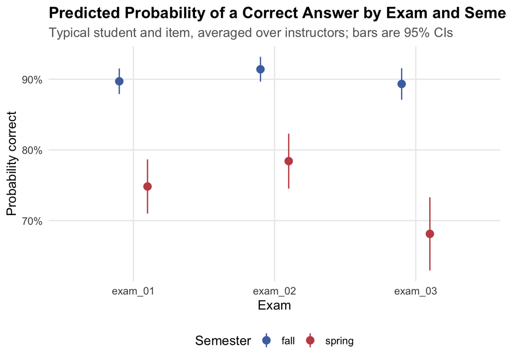

```r
estimate_means(d1, by = c("exam", "semester")) |>
  as_tibble() |>
  ggplot(aes(x = exam, y = Probability, color = semester)) +
  geom_pointrange(
    aes(ymin = CI_low, ymax = CI_high),
    position = position_dodge(width = 0.4)
  ) +
  scale_y_continuous(labels = scales::percent_format()) +
  scale_color_manual(values = c("#4C72B0", "#C44E52", "#55A868")) +
  labs(
    title = "Predicted Probability of a Correct Answer by Exam and Semester",
    subtitle = "Typical student and item, averaged over instructors; bars are 95% CIs",
    x = "Exam",
    y = "Probability correct",
    color = "Semester"
  ) +
  theme_minimal(base_size = 13) +
  theme(
    plot.title = element_text(face = "bold"),
    plot.subtitle = element_text(color = "grey40"),
    panel.grid.minor = element_blank(),
    legend.position = "bottom"
  )
```

## Assumption checks

```r
d1@optinfo$warnings
```

```
list()
```

```r
check_singularity(d1)
```

```
[1] FALSE
```

```r
check_collinearity(d1)
```

```
# Check for Multicollinearity

Low Correlation

          Term  VIF   VIF 95% CI adj. VIF Tolerance Tolerance 95% CI
          exam 1.84 [1.83, 1.86]     1.17      0.54     [0.54, 0.55]
      semester 2.10 [2.08, 2.12]     1.45      0.48     [0.47, 0.48]
    instructor 1.17 [1.17, 1.18]     1.02      0.85     [0.85, 0.86]
 exam:semester 3.11 [3.07, 3.14]     1.76      0.32     [0.32, 0.33]
```

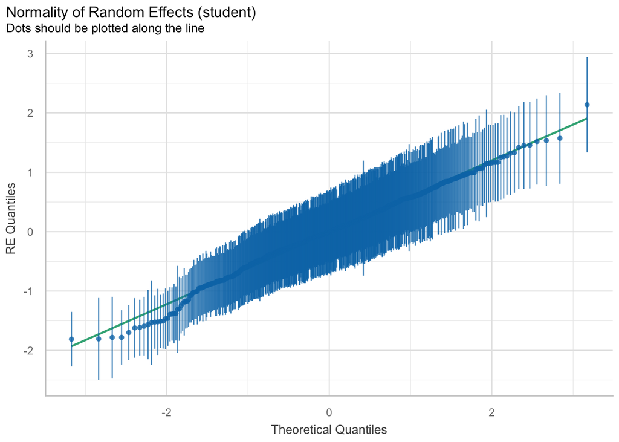

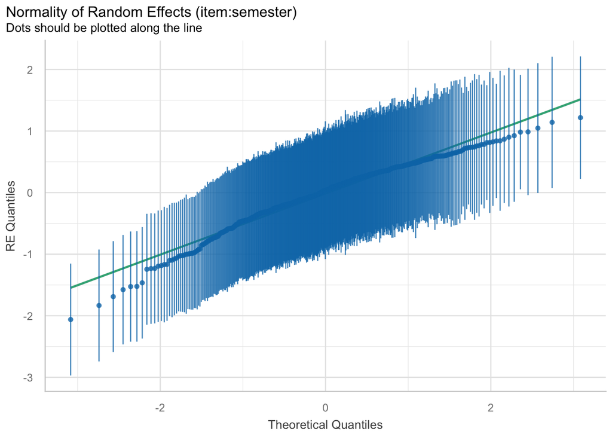

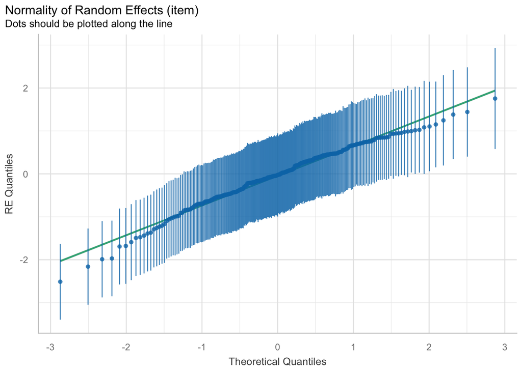

```r
check_normality(d1, effects = "random")
plot(check_normality(d1, effects = "random"))
```

```r
sim <- simulate_residuals(d1)
check_residuals(sim)
```

```
OK: Simulated residuals appear as uniformly distributed (p = 0.181).
```

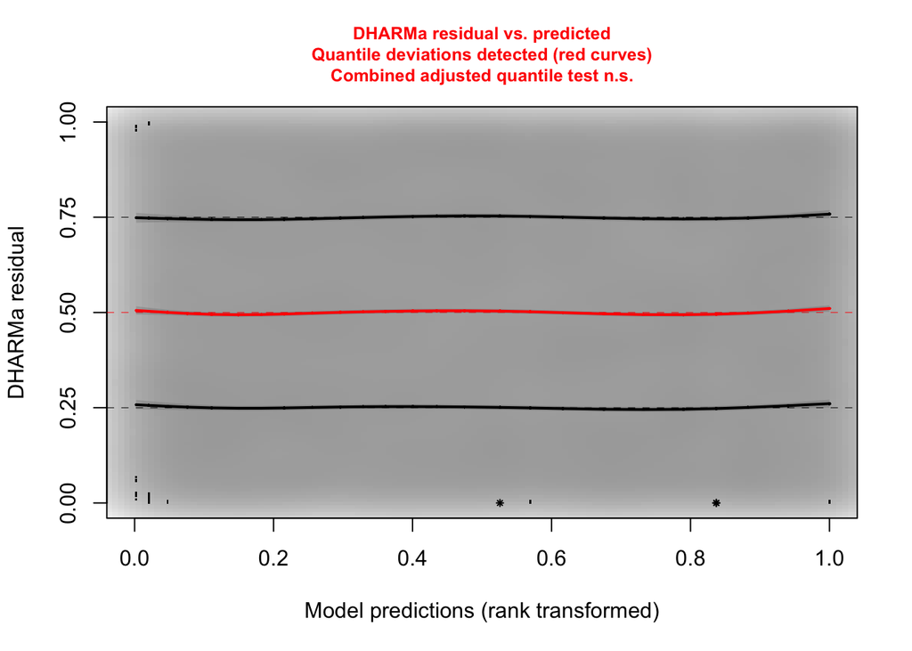

```
    Test for location of quantiles via qgam

data:  res
p-value = 0.07992
alternative hypothesis: both
```

```r
DHARMa::testQuantiles(sim)
```

```r
clean_shared |>
  filter(answered) |>
  summarise(n = n(), p_correct = mean(correct), .by = c(semester, exam))
```

```
# A tibble: 6 × 4
  semester exam        n p_correct
  <chr>    <chr>   <int>     <dbl>
1 fall     exam_01 12023     0.913
2 fall     exam_02 11725     0.912
3 fall     exam_03 10357     0.894
4 spring   exam_01  8218     0.748
5 spring   exam_02  8078     0.775
6 spring   exam_03  7192     0.691
```

```r
clean_shared |>
  filter(answered) |>
  count(semester, points)
```

```
# A tibble: 5 × 3
  semester points     n
  <chr>     <dbl> <int>
1 fall        0    3172
2 fall        1   30933
3 spring      0    6110
4 spring      0.5     1
5 spring      1   17377
```

```r
long |>
  distinct(semester, exam, instructor, id, attempt) |>
  count(semester, attempt)
```

```
# A tibble: 5 × 3
  semester attempt     n
  <chr>      <dbl> <int>
1 fall           1  1084
2 fall           2     2
3 spring         1   860
4 spring         2    13
5 spring         3     1
```

# Items with the biggest drift

```r
item_drift <- estimate_grouplevel(d1) |>
  as_tibble() |>
  filter(Group == "item:semester") |>
  mutate(
    semester = str_extract(Level, "[^:]+$"),
    item = str_remove(Level, ":[^:]+$")
  ) |>
  separate_wider_delim(
    item,
    delim = " | ",
    names = c("exam", "question_title"),
    too_many = "merge"
  ) |>
  select(exam, question_title, semester, Coefficient) |>
  pivot_wider(
    names_from = semester,
    values_from = Coefficient,
    names_prefix = "w_"
  ) |>
  mutate(drift = w_spring - w_fall) |>
  left_join(
    drift_items |>
      select(exam, question_title, difficulty_index_fall, difficulty_index_spring, difficulty_diff),
    by = c("exam", "question_title")
  ) |>
  arrange(drift)

# Largest drops beyond the average shift
item_drift |> slice_head(n = 10) |> select(-question_title)
```

```
# A tibble: 10 × 7
   exam    w_fall w_spring drift difficulty_index_fall difficulty_index_spring
   <chr>    <dbl>    <dbl> <dbl>                 <dbl>                   <dbl>
 1 exam_03  0.868   -0.942 -1.81                 0.985                   0.484
 2 exam_01  0.575   -1.17  -1.74                 0.929                   0.357
 3 exam_02  0.526   -1.01  -1.54                 0.955                   0.46
 4 exam_01  0.735   -0.791 -1.53                 0.982                   0.594
 5 exam_03  0.593   -0.918 -1.51                 0.953                   0.410
 6 exam_02  0.403   -1.10  -1.50                 0.926                   0.372
 7 exam_03  0.824   -0.647 -1.47                 0.988                   0.625
 8 exam_03  0.621   -0.768 -1.39                 0.968                   0.514
 9 exam_01  0.552   -0.756 -1.31                 0.964                   0.555
10 exam_02  0.582   -0.713 -1.29                 0.977                   0.654
# ℹ 1 more variable: difficulty_diff <dbl>
```

```r
# Items that held up best
item_drift |> slice_tail(n = 10) |> select(-question_title)
```

```
# A tibble: 10 × 7
   exam    w_fall w_spring drift difficulty_index_fall difficulty_index_spring
   <chr>    <dbl>    <dbl> <dbl>                 <dbl>                   <dbl>
 1 exam_01 -0.595    1.14   1.74                 0.942                   0.987
 2 exam_03 -1.23     0.523  1.75                 0.625                   0.625
 3 exam_03 -0.987    0.839  1.83                 0.818                   0.825
 4 exam_01 -1.10     0.729  1.83                 0.757                   0.830
 5 exam_02 -1.52     0.353  1.88                 0.467                   0.579
 6 exam_03 -1.58     0.548  2.12                 0.439                   0.535
 7 exam_02 -1.00     1.22   2.22                 0.898                   0.965
 8 exam_03 -1.83     0.447  2.28                 0.264                   0.398
 9 exam_03 -1.47     0.982  2.45                 0.632                   0.782
10 exam_03 -2.06     0.555  2.62                 0.189                   0.396
# ℹ 1 more variable: difficulty_diff <dbl>
```